# 7 — From Control to Learning

MDPs and environment design · SOC4180 Robot and AI

Hong Jeong

## The hinge of the course

For six weeks you have **derived** controllers. Transforms, kinematics, a balance model, gains, a filter — every line justified by physics you worked out.

From today you **specify problems** instead, and let an algorithm find the controller.

That is not a smaller job. It is a different one, and the failure modes move: the mathematics stops being where things go wrong, and the *specification* starts.

Today we write no learning code at all. We write the problem.

## The Markov decision process

Five pieces:

| Symbol | Name | For our robot |
| --- | --- | --- |
| $\mathcal{S}$ | states | joint angles, velocities, body attitude |
| $\mathcal{A}$ | actions | what we send to the servos |
| $P(s'\mid s,a)$ | transition | **MuJoCo** — we never write this down |
| $R(s,a)$ | reward | what we want, expressed as a number |
| $\gamma$ | discount | how much the future counts |

The goal: a policy $\pi(a\mid s)$ maximising expected discounted return $\mathbb{E}\left[\sum_t \gamma^t r_t\right]$.

**MuJoCo being the transition function is the whole reason this works.** We do not need to model the dynamics — we can simply run them.

## The loop, drawn

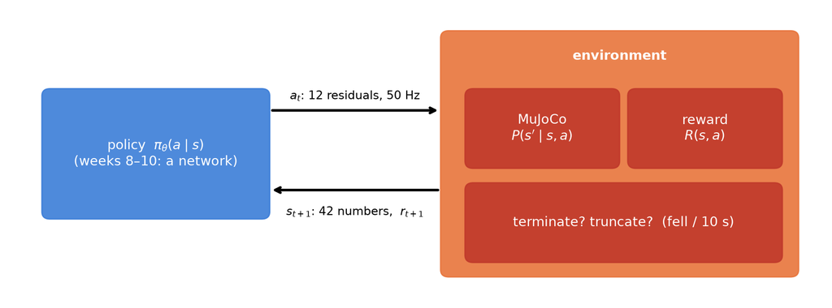

Everything inside the orange box is *ours to specify* and nothing inside it learns. Everything the algorithm touches is the blue box.

## What $\gamma$ means in seconds

The return from time $t$ is $G_t = \sum_{k \ge 0} \gamma^k\, r_{t+k}$. A constant reward $r$ sums to $r/(1-\gamma)$, so $1/(1-\gamma)$ is the **effective horizon**, in decisions:

| $\gamma$ | horizon (decisions) | at 50 Hz |
| --- | --- | --- |
| 0.9 | 10 | 0.2 s — less than one footstep |
| 0.99 | 100 | 2 s — three footsteps |
| 0.999 | 1000 | 20 s — longer than the episode |

The same $\gamma$ means a different *time* at a different control rate: the $0.99$ that suits 50 Hz is a 0.2 s horizon at 500 Hz. That is a second reason the control rate below is a design decision and not a detail.

## Markov, honestly

The Markov property says the current state contains everything needed to predict the future.

Our robot **violates this**, and knowingly:

- we observe gravity and gyroscope, not true attitude (Week 6)
- we cannot see the ground ahead
- actuator state, contact history, and momentum are only partly visible

Formally we have a *partially observable* MDP. The standard practical answer is to stack recent observations and include the previous action, giving the policy a short memory.

**Pretending it is Markov, then compensating, is normal practice.** Knowing that you are doing it is the difference between engineering and cargo culting.

## Design decision 1: what is an action?

Three plausible choices, and they are not equally good:

| Action | Consequence |
| --- | --- |
| **Joint torques** | Most general, and the policy must learn gravity compensation from scratch |
| **Absolute joint angles** | Servos do the hard work; but every output must specify a whole posture |
| **Residuals about a nominal pose** | The policy nudges a stance that already works |

We use the third: $\text{target} = q_{\text{nominal}} + \kappa\,a$, with the nominal being the Week 4 crouch and $\kappa = 0.3$ rad.

An untrained policy outputs roughly zero, which means it **starts by standing in a sensible crouch** rather than flailing. That single choice removes an enormous amount of wasted exploration.

## Design decision 2: how fast does it think?

Physics runs at 500 Hz. Does the policy?

**No.** It runs at **50 Hz**, holding each action for 10 physics steps.

Reasons, all from Week 0’s timescale table:

- a leg cannot move meaningfully in 2 ms, so deciding that often is wasted
- a network evaluated at 500 Hz costs 10× the compute for no benefit
- longer intervals mean fewer decisions per episode, so credit assignment is easier
- real robots deploy policies at 50 Hz for exactly these reasons

The servos still run at 500 Hz underneath. **The policy sets targets; the PD loop chases them.** The layered structure from Week 0 survives intact.

## Two clocks

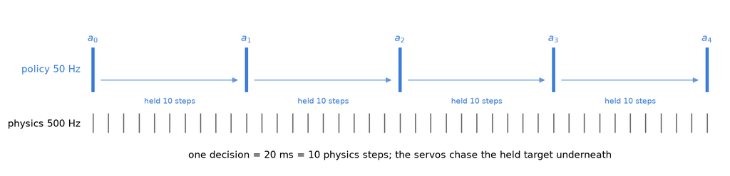

## Design decision 3: when does an episode end?

- **Terminate** when the robot has fallen — body below 0.5 m, or tilted more than 0.7 rad from upright. Continuing to simulate a heap on the floor teaches nothing and wastes compute.
- **Truncate** at 10 seconds, so a policy that stands still forever still yields a finite episode.

The distinction matters to the algorithm: **termination means the future is genuinely worth nothing; truncation means we merely stopped watching.** Bootstrapping past a truncation is correct; bootstrapping past a termination is a bug that quietly teaches the robot that falling is survivable.

## The environment

```
observation : 42 numbers
action      : 12 (the twelve leg joints only)
control     : 50 Hz over 500 Hz physics  (hold each action 10 steps)
episode     : 500 decisions = 10 s
```

Forty-two observations: gravity (3), gyroscope (3), and for each of twelve joints its angle, velocity, and last commanded residual. **Arms and waist are frozen** — seventeen dimensions the walking problem does not need.

## The observation, drawn to scale

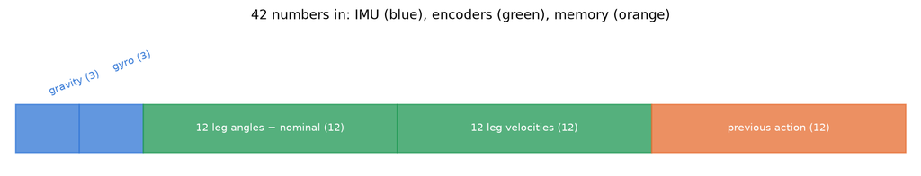

Compare it with week 6’s 64: the arms and the waist are gone, and the **previous action** has been added — the one-step memory that papers over the missing Markov property.

## Validate the contract

Gymnasium ships a checker. Use it, every time.

```
env_checker: PASSED
```

It verifies the boring things that silently break training: shapes and dtypes matching the declared spaces, `reset` accepting a seed and returning `(obs, info)`, `step` returning five values, and determinism given a seed.

A subtly non-conforming environment does not crash. **It trains badly, and you spend a week blaming the algorithm.**

## Two baselines before any learning

```
  do nothing (hold the crouch)   return   774.09  500 steps  survived
  uniform random                 return    22.47   25 steps  FELL
```

**Always measure these first.** “Do nothing” is the number a policy must beat to have learned anything at all; random is the number it must beat to be a policy.

## Can the env even express what we know?

We already have a working controller. If the environment cannot represent it, no algorithm will find anything better.

```
analytic walker inside the env: travelled +0.239 m, pelvis 0.561 m
  FELL;  actions hit the limit on 35.7% of steps
  (at 500 Hz with no action limit it walks +0.99 m)
```

**It falls.** The controller that worked three weeks ago cannot survive its own environment.

## Diagnose it

Two suspects: the action range is too narrow, and the control rate is too slow. Separate them.

```
 scale    Hz   travel       z  clipped  outcome
   0.3    50   +0.239   0.561    35.7%  FELL
   0.3   100   +0.213   0.575    35.1%  FELL
   0.3   200   +0.234   0.562    35.9%  FELL
   0.6    50   +1.553   0.557    18.1%  FELL
   0.6   100   +1.567   0.564    19.1%  FELL
   0.6   200   +1.560   0.571    19.1%  FELL
   1.0    50   +1.564   0.564     0.0%  FELL
   1.0   100   +1.047   0.717     0.0%  survived
   1.0   200   +1.049   0.717     0.0%  survived
```

**Both matter, independently.** At $\kappa=0.3$ a third of the actions are clipped and it fails at every rate. At $\kappa=1.0$ clipping stops, but 50 Hz still fails. Only $\kappa=1.0$ **and** ≥100 Hz reproduces the walk — 1.05 m, against 0.99 m at 500 Hz.

## The same table, as a picture

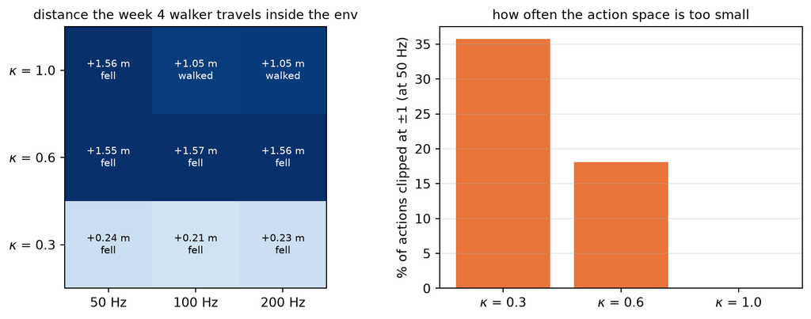

Only the top-right corner walks. Reading down the right column: the rate was fine and the actions were being cut off. Reading across the top row: the actions were fine and the rate was too slow. Two separate constraints, each sufficient to break it.

## What that experiment actually taught

**Your action space defines the set of reachable behaviours.** A solution outside it is not merely hard to find; it does not exist in your problem. Nothing in a learning curve will ever tell you this — the run just plateaus.

So why keep $\kappa = 0.3$ and 50 Hz as our defaults?

Because those are the values the locomotion literature trains with, and learned policies *do* find good gaits inside that envelope. They simply find **different gaits from ours** — smaller, faster corrections rather than large scripted swings.

The lesson is not “our defaults are wrong”. It is that an environment is a **commitment about what kind of solution you expect**, and you should know what you have committed to.

## One trap in that table

Nothing got better. **A 200 Hz episode contains four times as many steps as a 50 Hz one**, and each step adds reward.

> Return is only comparable between runs that share an episode structure.

Report metrics that mean something physically — distance travelled, time upright, average velocity — alongside return. Week 9 leans on this hard.

## The reward, for now

```
  forward_velocity   +0.0523
  tracking           +0.4485
  upright            +0.9999
  effort             +0.0000
  smooth             +0.0000
  alive              +1.0000
  stand_still        +1.0000
  air_time           +0.0000
```

Four terms and an alive bonus:

- **track** a target forward velocity — the actual objective
- stay **upright** — shaping, to make early learning less hopeless
- pay for **effort** and for **jerky** actions — so it does not thrash
- **alive bonus** — so early death is worse than mediocre survival

Every one of those is a decision, and every one is exploitable. **Week 9 breaks them on purpose.**

## The shape of each term

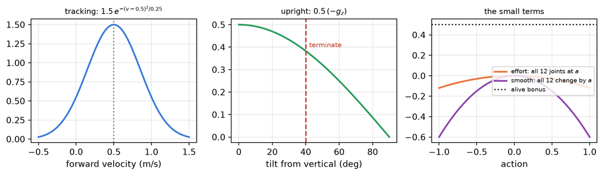

## Lab class: on your laptop

```bash
uv run weeks/07-mdp/lab_env.py
```

`G1WalkEnv`, stepping at 50 Hz in real time in the viewer. Keys `1`–`4` pick a policy: hold the crouch, uniform random, the week 4 walker as actions, and `my_policy` — complete as shipped: the ankle strategy, both ankles driven against `obs[0:3]`. On the robot: a white arrow for `obs[0:3]`, a reward bar above the head, yellow feet when airborne. Every episode ends with return, steps, and **terminated** or **truncated**.

| Step | Do | Right looks like |
| --- | --- | --- |
| 1 | `1`, `2`, `3`; then `ACTION_SCALE = 1.0`, `CONTROL_HZ = 100`, `3` | 774; 32 and a fall; 357 and a fall at 4.3 s; then 1805 and a metre |
| 2 | `my_policy` = bend the knees | `ENTER`: upright up, effort down, tracking unchanged |
| 3 | `my_policy` periodic on hip pitch | a termination at 1.5 s, read off the episode line |
| 4 | ctrl-drag under `1` and under `4` | hold falls at 70 N; the ankle strategy survives 75 and falls at 80; hip roll instead changes nothing |
| 5 | `REWARD_WEIGHTS = {"alive": 0.0}` | the numbers change and the behaviour does not |

## Lab class: `env_run.py`, one episode term by term

```bash
uv run weeks/07-mdp/env_run.py --policy walker --action-scale 1.0 --hz 100
uv run weeks/07-mdp/env_run.py --policy lean --push 75
uv run weeks/07-mdp/env_run.py --policy hold --push 70 --no-viewer
```

Five policies of a few lines each; one episode printed as a row per second with the reward split by term; the episode line; `--push` shoves the torso for 0.2 s through `xfrc_applied`; then the replay.

```
 t (s)   x (m)  reward/s    tracking    upright     effort     smooth      alive
  1.00  -0.017     77.16       27.28      24.99      -0.00      -0.00      25.00
  ...
episode: return   774.09  500 decisions  10.00 s  travelled -0.019 m  TRUNCATED (time ran out)
return by term: tracking +274.2, upright +249.9, effort +0.0, smooth +0.0, alive +250.0
```

| Step | Does | Calls |
| --- | --- | --- |
| 1 | the MDP written down | `G1WalkEnv`, `observation_space`, `action_space`, `reward_weights` |
| 3 | reset, decide / act / score until done | `env.reset`, `env.step`, `info`, `xfrc_applied` |
| 4 | the episode line and the split by term |  |
| 6 | replay | `launch_viewer(passive=True)` |

## Exercises

1. **Termination as a reward.** Remove the alive bonus. Does the policy space change, or only the incentives? Predict before running.
2. **Observation ablation.** Remove the previous action from the observation. Argue whether the problem is still (approximately) Markov.
3. **Torque actions.** Add a mode that outputs torques instead of residuals. Roll out the zero action in each. Why does one stand and the other collapse?
4. **Find the rate limit.** Bisect the control rate between 50 and 100 Hz at $\kappa = 1.0$. Where exactly does the walker start surviving?
5. **Fair comparison.** Design a metric that compares 50 Hz and 200 Hz runs honestly. Show it ranks the runs differently from raw return.
6. **Truncation bug.** Explain what a policy would learn if truncation were treated as termination. Which of our four reward terms would it exploit?

## Next week

**08 — policy gradients and PPO.** The environment is written and checked, the baselines are measured, and we know what it can and cannot express.

Now we let an algorithm search it — starting on something far easier than a humanoid, so that when PPO meets the hard problem you already know what a healthy learning curve looks like.